# Practical Machine Learning Coursework

## Packages

Loading in the relevant packages and setting the seed for reproducibility.

```r
library(caret)
library(randomForest)
set.seed(1000)
```

## Obtaining Data

Load in the training and testing data (saved locally in the working directory)

```r
#reading in the training and testing data.
rawTrain <- read.csv("pml-training.csv")
testing <- read.csv("pml-testing.csv")
```

## Preprocessing

I first removed the rows where the new window column was equal to ‘yes’, as this data is not present in the test data.

```r
# removing rows with new window = yes - not in test set
rawTrain <- subset(rawTrain, new_window=="no")
```

I then split the training data into a training and cross validation set. I used a 60% split, due to the large amount of data. The cross validation set was used to assess out of sample error.

```r
# partitioning training data into a training and cross validation set
inTrain <- createDataPartition(rawTrain$classe,p=0.6,list=FALSE)
training <- rawTrain[inTrain,]
crossVal <- rawTrain[-inTrain,]
```

I then removed the features/columns with near zero variance.

```r
# removing columns with near zero variance
ZeroVar <- nearZeroVar(training)
training <- training[,-ZeroVar]
```

I then removed the features/columns with 50% or more NA’s and missing values.

```r
#removing columns with lots of NA's and missing values
pctMissing <- sapply(training, function(x) {
  sum(!(is.na(x) | x == ""))
})

missingCol <- names(pctMissing[pctMissing < 0.5 * length(training$classe)])
```

In addition, I removed the features/columns that are descriptive.

```r
# removing descriptive features/columns
descriptiveCol <- c("X", "user_name", "raw_timestamp_part_1", "raw_timestamp_part_2",
                "cvtd_timestamp", "new_window", "num_window")
removeCol <- c(missingCol ,descriptiveCol)

training <- training[,!names(training) %in% removeCol]
```

## Training Model

At first, I chose the random forest method to train my model, due to it’s wide and accurate use in classification problems. This model returned good out of sample errors and scored well in the prediction exercise, therefore there was no need to attempt another method, such as boosting or linear discriminant analysis.

```r
# creating model using random forest method. Reduced to 100 trees to speed up processing
modFit <- train(classe ~ ., method = "rf", data=training, ntree=100)
```

## Validating Model

I conducted both in sample and out of sample error assessments.

### In Sample Validation

For the in sample error, I compared the training data values to the predictions based on this data and the random forests model. The accuracy was found to be 1. This is because the model was trained on the training data, which can result in some overfitting. A more useful assessment is out of sample error.

```r
# in sample error using training data
predTraining <- predict(modFit, training)
confusionMatrix(predTraining, training$classe)
```

```
## Confusion Matrix and Statistics
##
##           Reference
## Prediction    A    B    C    D    E
##          A 3283    0    0    0    0
##          B    0 2231    0    0    0
##          C    0    0 2012    0    0
##          D    0    0    0 1889    0
##          E    0    0    0    0 2117
##
## Overall Statistics
##
##                Accuracy : 1
##                  95% CI : (0.9997, 1)
##     No Information Rate : 0.2847
##     P-Value [Acc > NIR] : < 2.2e-16
##
##                   Kappa : 1
##  Mcnemar's Test P-Value : NA
##
## Statistics by Class:
##
##                      Class: A Class: B Class: C Class: D Class: E
## Sensitivity            1.0000   1.0000   1.0000   1.0000   1.0000
## Specificity            1.0000   1.0000   1.0000   1.0000   1.0000
## Pos Pred Value         1.0000   1.0000   1.0000   1.0000   1.0000
## Neg Pred Value         1.0000   1.0000   1.0000   1.0000   1.0000
## Prevalence             0.2847   0.1935   0.1745   0.1638   0.1836
## Detection Rate         0.2847   0.1935   0.1745   0.1638   0.1836
## Detection Prevalence   0.2847   0.1935   0.1745   0.1638   0.1836
## Balanced Accuracy      1.0000   1.0000   1.0000   1.0000   1.0000
```

### Out of Sample Validation (using Cross Validation)

For the out of sample error, I compared the cross validation data values to the predictions based on this data and the random forests model. The accuracy was 0.99, which is very good. Therefore the out of sample error is very low.

```r
# out of sample error using cross validation data
predVal <- predict(modFit, crossVal)
confusionMatrix(predVal, crossVal$classe)
```

```
## Confusion Matrix and Statistics
##
##           Reference
## Prediction    A    B    C    D    E
##          A 2180   10    0    0    0
##          B    4 1472   14    0    5
##          C    3    5 1321   18    3
##          D    0    0    5 1240    6
##          E    1    0    0    0 1397
##
## Overall Statistics
##
##                Accuracy : 0.9904
##                  95% CI : (0.9879, 0.9924)
##     No Information Rate : 0.2847
##     P-Value [Acc > NIR] : < 2.2e-16
##
##                   Kappa : 0.9878
##  Mcnemar's Test P-Value : NA
##
## Statistics by Class:
##
##                      Class: A Class: B Class: C Class: D Class: E
## Sensitivity            0.9963   0.9899   0.9858   0.9857   0.9901
## Specificity            0.9982   0.9963   0.9954   0.9983   0.9998
## Pos Pred Value         0.9954   0.9846   0.9785   0.9912   0.9993
## Neg Pred Value         0.9985   0.9976   0.9970   0.9972   0.9978
## Prevalence             0.2847   0.1935   0.1744   0.1637   0.1836
## Detection Rate         0.2837   0.1916   0.1719   0.1614   0.1818
## Detection Prevalence   0.2850   0.1946   0.1757   0.1628   0.1819
## Balanced Accuracy      0.9973   0.9931   0.9906   0.9920   0.9950
```

## Important Variables

A plot to show the 10 most important variables:

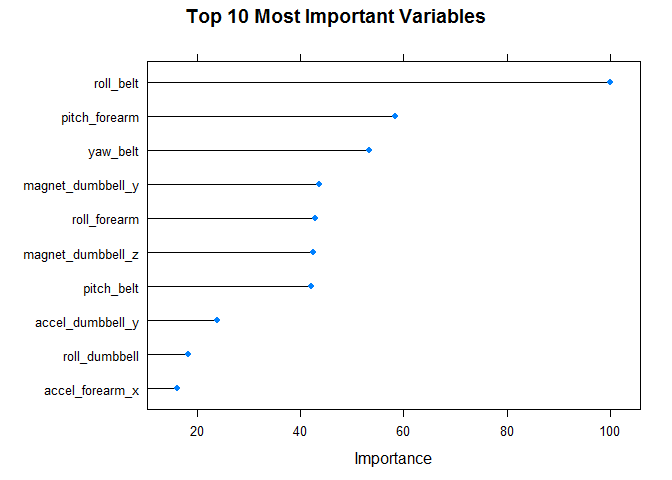

## Predicting Test Set Classes

The following shows the output of the test data class predictions using the derived random forest model. All predictions were found to be correct when ran through the week 4 quiz.

```r
# predictions on testing set
predTest <- predict(modFit, testing)
predTest
```

```
##  [1] B A B A A E D B A A B C B A E E A B B B
## Levels: A B C D E
```